# Machine-Learning-vol.11-決定木

## 11.1 決定木の利点

決定木（Decision Tree）は､**条件分岐の繰り返し**によって分類問題を解く**教師あり学習**のモデルです｡枝分かれによって**木構造**を作ることから､その名が付けられています｡シンプルなアルゴリズムながら独自の強みを持っており､現在でもデータサイエンスの現場で広く利用されています｡一方で弱みも持っていますが､それを補うモデルが既に開発されています｡本章では､**その弱みを補うモデル**についても解説します｡また､決定木は分類でも回帰でも利用することができますが､本章では分類問題についてのみ取り扱います｡

[figure not shown]

ちなみに､決定木のアルゴリズムで分類問題を解くと､下の図に表すような**軸に垂直な直線による境界線**が引かれます｡これは､決定木が**ひとつの条件分岐につき､ひとつの特徴量だけに注目するため**です｡

[figure not shown]

まずは､決定木の利点･選ばれる理由を紹介します｡ここまでの講座で､**ロジスティック回帰**や**SVM**などの有用な分類機を既に紹介していますが､決定木はそれらに対してどのような優位性があるのでしょうか？

### 11.1.1 意味解釈性が高い

意味解釈性とは､その名の通り**分析結果の意味がどれだけ解釈しやすいかという度合い**です｡意味解釈性が高ければ､**分析者が分析作業をしやすい**だけでなく､**機械学習についての知識がない人に対しての説明も容易になります｡**例えば､ビジネスのシーンで新たな施策を打つ際の根拠を説明できたり､医療の現場で疾病判定の根拠を説明できたりします｡これがない場合､**｢よくわからないけど､機械学習にかけてみたらこの結果になった｣**としか言えなくなってしまいます｡その場合､機械学習の知識がない人たちに大きな不安を感じさせることになりかねません｡

[figure not shown]

### 11.1.2 前処理の手間がかからない

第二の利点は､**前処理の手間がかからない**という点です｡決定木による分析においては､**標準化やダミー変数化といった前処理が必要ありません**｡データが手に入ってすぐに分析を始めることが可能なので､分析者にとって非常にありがたい利点です｡

[figure not shown]

### 11.1.3 学習が高速

第三の利点は､**学習が早い**ということです｡これは､決定木は条件分岐の繰り返しという非常に単純な構造を基礎に作られているためです｡しかし､ここには柔軟性とのトレードオフも存在します｡

[figure not shown]

## 11.2 情報利得の最大化

決定木の理想は､**複数サンプルを最もきれいに分割する条件分岐が行われること**です｡決定木は分類モデルである以上､**各リーフに単一クラスのサンプルのみが存在する**ような､各クラスを完全に分類できる状態を目指します｡そのため､**｢一回の分岐でノード内のクラスがどれだけきれいに分割されたか｣**を表す指標を目的関数に設定しています｡**情報利得の最大化**とは､そのコンセプトを定式化したものです｡

[figure not shown]

### 11.2.1 不純度

不純度（Impurity）とは､**｢ひとつのノード内に複数のクラスがどれだけ混在しているか｣**を表す指標です｡これを定義するためには､複数クラスが混在しているほど大きく､単一クラスがまとまっているほど小さい指標を定める必要があります｡その指標として情報､以下に示す**エントロピー**と**ジニ不純度**がよく利用されます｡

[figure not shown]

#### 情報エントロピー

情報エントロピーは､**｢ノード内の複数クラスの混合割合｣**という観点で定義される不純度です｡グラフを見ていただいてわかる通り､値は混合割合が0か1に近づくほど小さくなり､逆に半々の割合で混合されているほど大きくなることがわかります｡

$$ I_H(D) = -\sum^{m}_{i} P(i | D) log{P(i | D)} $$

[figure not shown]

#### ジニ不純度

ジニ不純度は､**｢ノード内からランダムにサンプルを取り出すとき､特定クラスのサンプルを狙って取り出せない確率｣**という観点で定義される不純度です｡グラフを見ていただいてわかる通り､情報エントロピーとほぼ同じ形状をしていることがわかります｡scikit-learnではジニ不純度がデフォルトに設定されていますが､どちらを使っても特別な違いは生まれません｡

$$I_G(D) = \sum^{c}_{i=1}p(i \ |\ D)(1 - p(i \ |\ D)) = 1 - \sum^{c}_{i=1}p(i \ |\ D)^2$$

[figure not shown]

### 11.2.2 情報利得

情報利得とは､**｢その条件分岐で､どれだけきれいに各クラスを分離出来たか｣**を表す指標です｡数学的には､**条件分岐の前後で不純度の総和の差額です**｡決定木におけるそれぞれの条件分岐は､情報利得を最大化するように行われています｡決定木の条件分岐においては､情報利得の最大化を目指して､どの特徴量に着目してどのような境界を定めるべきかを考えています｡

$$ \begin{align} IG(D_p, f) &= (親ノードの不純度) - (子ノードの不純度の合計)\\ &= I(D_p) - \Bigl( \frac{N_{left}}{N_p}I(D_{left}) + \frac{N_{right}}{N_p}I(D_{right}) \Bigr) \end{align} $$

- $D_p$: 親ノード内のデータ
- $D_left$: 左側の子ノード内のデータ
- $D_right$: 右側の子ノード内のデータ
- $f$: 条件分岐で着目する特徴量
- $IG(D_p, f)$: 親ノード $D_p$ から､特徴量fに注目した分岐の情報利得
- $I(D_p)$: 親ノードの不純度
- $I(D_{left})$: 左の子ノード内のデータから導かれる不純度
- $I(D_{right})$: 右の子ノード内のデータから導かれる不純度
- $N_p$: 親ノードに含まれるサンプル数
- $N_{left}$: 左の子ノードに含まれるサンプル数
- $N_{right}$: 右の子ノードに含まれるサンプル数

## 11.3 決定木の実装

今回は決定木をirisデータを利用して実装してみます｡

### 11.3.1 学習の実行

```python
# 必要なライブラリをインポート
import numpy as np
import pandas as pd
import matplotlib.pyplot as plt
%matplotlib inline
from sklearn.datasets import load_iris
from sklearn.model_selection import train_test_split

# データセットのロード
iris = load_iris()
X_1 = iris.data[:,[2,3]]
y_1 = iris.target

# データセットの分割
X_1_train, X_1_test, y_1_train, y_1_test = train_test_split(X_1, y_1, test_size=0.3, random_state=0)
```

決定木による学習は､**sklearn.tree**の**DecisionTreeClassifier**クラスを利用して実行できます｡

```python
# 決定木による学習
from sklearn.tree import DecisionTreeClassifier
tree_1 = DecisionTreeClassifier(random_state=0)
tree_1.fit(X_1_train, y_1_train)
```

```
DecisionTreeClassifier(class_weight=None, criterion='gini', max_depth=None,
            max_features=None, max_leaf_nodes=None,
            min_impurity_split=1e-07, min_samples_leaf=1,
            min_samples_split=2, min_weight_fraction_leaf=0.0,
            presort=False, random_state=0, splitter='best')
```

### 11.3.2 学習結果の評価

```python
# 決定曲線をプロットする関数
def plot_decision_regions(X, y, classifier, resolution=0.02):
    from matplotlib.colors import ListedColormap
    markers = ("s", "x", "o", "^", "v")
    colors = ("red", "blue", "lightgreen", "gray", "cyan")
    cmap = ListedColormap(colors[:len(np.unique(y))])
    x1_min, x1_max = X[:, 0].min()-1 , X[:, 0].max() +1
    x2_min, x2_max = X[:, 1].min()-1 , X[:, 1].max() +1
    xx1, xx2 = np.meshgrid(np.arange(x1_min, x1_max, resolution), np.arange(x2_min, x2_max, resolution))
    Z = classifier.predict(np.array([xx1.ravel(), xx2.ravel()]).T)
    Z = Z.reshape(xx1.shape)
    plt.contourf(xx1, xx2, Z, alpha=0.4, cmap=cmap)
    plt.xlim(xx1.min(), xx1.max())
    plt.ylim(xx2.min(), xx2.max())
    for idx, cl in enumerate(np.unique(y)):
        plt.scatter(x=X[y == cl, 0], y=X[y == cl, 1], alpha=0.8, c=cmap(idx),marker=markers[idx], label=cl)
```

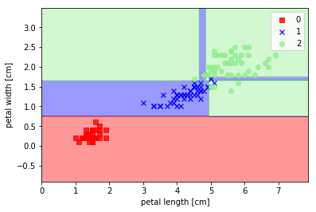

```python
# 決定曲線をプロット
plot_decision_regions(X_1, y_1, tree_1)
plt.xlabel('petal length [cm]')
plt.ylabel('petal width [cm]')
plt.legend(loc='best')
plt.show()
```

この決定曲線を見ると､右上の領域で**過学習**を起こしてしまっていることがわかります｡過学習への対策については､11.4節以降で紹介します｡

```python
# 精度の確認
print('train: {:.3f}'.format(tree_1.score(X_1_train, y_1_train)))
print('test : {:.3f}'.format(tree_1.score(X_1_test, y_1_test)))
```

```
train: 0.990
test : 0.956
```

### 11.3.3 木構造の可視化

scikit-learnには**学習後の決定木のなしている木構造を.dotファイルの画像形式で出力する機能**があります｡これによって､決定木による分類の様子が可視化できます｡.dotファイルの出力はGraphVizというライブラリを利用して行うことができます｡**GraphViz**をまだインストールしていない場合は､下記のコマンドをターミナルに打ち込んでインストールしてください｡

```
$ pip install graphviz
```

[figure not shown]

```python
# .dotファイルをエクスポート
from sklearn.tree import export_graphviz
export_graphviz(tree_1, out_file='tree_1.dot', feature_names=['petal length', 'petal width'],
               class_names=['setosa', 'versicolour', 'virsinica'], impurity=False, filled=True)
```

#### ファイル形式の変換

次に､**.dotファイル**はそのままでは開くことができないので､扱いやすい**.pngファイル**の形式にに変換します｡ターミナルあるいはコマンドプロンプトから､cdなどのコマンドを用いて､**このnotebookが保存されているディレクトリに移動して**､以下のコマンドを実行してください｡.dotファイルはnotebookと同じディレクトリに出力されるようになっています｡

```
dot -Tpng tree_1.dot -o tree_1.png
```

参考資料:  
[【保存版】Macでターミナルで使える基本のコマンド8選](http://qiita.com/kenju/items/77a2dc1b6a60697b1133)  
[Linuxコマンド:Windowsコマンド対応表](http://qiita.com/asmin/items/d53e71ed98a377ca7823)

画像を出力する際には､**OpenCV**というライブラリを利用します｡OpenCVは画像を扱うライブラリで､保存した画像を読み込み､matplolibによって表示させることができます｡まだインストールをされていない場合は､ターミナルで以下のコマンドを実行してください｡

`$ pip install opencv-python`

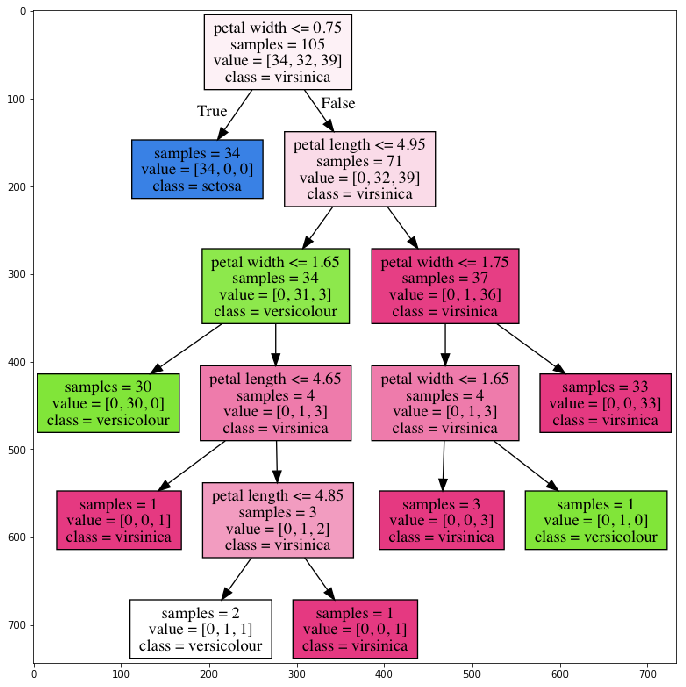

```python
# 木構造を画像として出力
import cv2
img = cv2.imread('tree_1.png')
plt.figure(figsize=(12, 12))
plt.imshow(img)
plt.show()
```

## 11.4 過学習の原因

決定木の最大の問題点は**過学習が起こりやすくなってしまうこと**です｡ここでは､その原因を2つほどピックアップしました｡この後の節で紹介する手法はこれらの原因を潰すためのアプローチになっています｡

### 11.4.1 深いノードでの条件分岐

決定木は､**深いノードにおける分岐で過学習を起こしやすくなります**｡決定木では､条件分岐をひたすらに繰り返していけば､最終的にはすべてのノードを純粋にすることが可能です｡しかし､**そうして定まったモデルの汎化性能が高いとは限りません｡**枝分かれが繰り返されると､各ノード内のサンプルが減ってきます｡すると､**そのノードで行われる条件分岐は数少ないサンプルを頼りに決定することになり､データ全体を反映したものにはならない**のです｡これでは､バリアンスが大きくなりすぎてしまいます｡

[figure not shown]

### 11.4.2 解の不安定さ

決定木の境界線は､**ちょっとしたサンプリングの違いによって大きく変わります**｡これは､**サンプリングされたtrainデータによって情報利得を最大化させる特徴量が変わってしまったため**です｡下図がその一例です｡これもある意味､**一部のデータへの過剰適合**と捉えることが出来ます｡こうした不安定さを緩和するような対策も､汎化性能を上げる上で必要になります｡

[figure not shown]

## 11.5 剪定

ここからは､決定木の**過学習を抑える手法**を紹介します｡その中でも最も簡単なものが剪定です｡剪定（pruning）とは､**決定木の条件分岐を途中で打ち切り､深い枝での条件分岐を抑える手法**です｡木の枝の手入れをして短く整える様子になぞらえて､このように名前が付けられています｡これは､インスタンスの引数**max_depth**を指定することで実行できます｡**max_depthは木の深さ（枝分かれの回数）**を制限するハイパーパラメータです｡これによって､正則化のようにバリアンスを抑えることができます｡

[figure not shown]

```python
# 決定木による学習
# max_depthを指定
from sklearn.tree import DecisionTreeClassifier
tree_2 = DecisionTreeClassifier(random_state=0, max_depth=3)
tree_2.fit(X_1_train, y_1_train)
```

```
DecisionTreeClassifier(class_weight=None, criterion='gini', max_depth=3,
            max_features=None, max_leaf_nodes=None,
            min_impurity_split=1e-07, min_samples_leaf=1,
            min_samples_split=2, min_weight_fraction_leaf=0.0,
            presort=False, random_state=0, splitter='best')
```

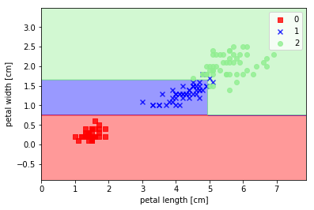

```python
# 決定曲線をプロット
plot_decision_regions(X_1, y_1, tree_2)
plt.xlabel('petal length [cm]')
plt.ylabel('petal width [cm]')
plt.legend(loc='best')
plt.show()
```

決定境界のプロットにより､過学習が抑制されることがわかりました｡

## 11.6 アンサンブル学習とは

アンサンブル学習とは､**それほど性能が高くないモデル（弱学習器）を複数組み合わせることによって､汎化性能を向上させる手法**のことです｡詳しい理論立てはいまだになされていませんが､**経験的に汎化性能を大きく向上させることが知られています**｡決定木の過学習はアンサンブル学習を用いて防ぐことができます｡また､アンサンブル学習には**バギング**と**ブースティング**の大きく2種類があります｡

### 11.6.1 バギング

バギング(Bootstrap AGGregatING, bagging)とは､**複数のモデルを独立に学習させて､それぞれのモデルの出力を平均（回帰の場合）または多数決（分類の場合）することによって出力を決める手法**のことです｡バギングの場合は､**個々のモデルはあえて過学習させる**などして複雑なモデルにしておきます｡そのような過学習を起こした学習器で平均や多数決をとり､**様々な過学習の傾向が打ち消しあって最終的にちょうどいい決定境界をつくること**がバギングの目標です｡決定木を用いたバギングには､**ランダムフォレスト**という手法があります｡

[figure not shown]

#### ブートストラップ法

ブートストラップ法とは､**データ全体の中から重複を許してtrainデータを選ぶ手法**です｡ランダムフォレストでは､それぞれの決定木を学習させるときにブートストラップ法によってtrainデータをつくります｡毎回違ったtrainデータを与えることによって､それぞれの木にランダム性を与えています｡

[figure not shown]

### 11.6.2 ブースティング

ブースティング（Boosting）とは､**ひとつのモデルの間違いをうまく訂正するようなモデルを次々に（逐次的に）つくることで､高い汎化性能を実現しようとする手法**です｡バギングはモデルの出力の平均をとるために､対等な立ち位置のモデルを独立に学習させましたが､ブースティングは**大元のモデルを最適化するための補助的なモデル**を逐次的に学習させていきます｡**決定木を用いたブースティング**の手法は勾配ブースティング木と呼ばれます｡

## 11.7 ランダムフォレスト

ランダムフォレストとは､**決定木を用いたバギングの手法**です｡独立して学習させた多数の決定木を束ね､まるで多数の木が集まって森ができたような構造をなしています｡最終的な出力は､あえて過学習させたそれぞれの決定木の予測ラベルを多数決して決めます（厳密には､予測確率を出力して､その平均が最も大きかったクラスを採用しています）｡

[figure not shown]

### 11.7.1 ランダムフォレストのパラメータ

ランダムフォレストの場合は､**調整するべきパラメータはほとんどありません**｡強いて言えば､下に示す**n_estimators**くらいのものです｡

#### n_estimators

n_estimatorsは､**ランダムフォレストに含める決定木の本数**です｡**多ければ多いほど性能が安定**しますが､**一方で学習時間や予測時間も増加**していきます｡コンピュータのメモリに余裕があれば､増やしてみるのも良いでしょう｡

### 11.7.2 学習の実行

ランダムフォレストは､**sklearn.ensemble**の**RandomForestClassifier**クラスを利用して実行できます｡

```python
# ランダムフォレストによる学習
from sklearn.ensemble import RandomForestClassifier
rfc_1 = RandomForestClassifier(random_state=0, n_estimators=10)
rfc_1.fit(X_1_train, y_1_train)
```

```
RandomForestClassifier(bootstrap=True, class_weight=None, criterion='gini',
            max_depth=None, max_features='auto', max_leaf_nodes=None,
            min_impurity_split=1e-07, min_samples_leaf=1,
            min_samples_split=2, min_weight_fraction_leaf=0.0,
            n_estimators=10, n_jobs=1, oob_score=False, random_state=0,
            verbose=0, warm_start=False)
```

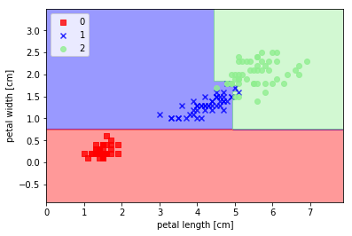

```python
# 決定境界の出力
plot_decision_regions(X_1, y_1, rfc_1)
plt.xlabel('petal length [cm]')
plt.ylabel('petal width [cm]')
plt.legend(loc='upper left')
plt.show()
```

```python
# 正答率を出力
print('train accuracy: %.3f' % rfc_1.score(X_1_train, y_1_train))
print('test  accuracy: %.3f' % rfc_1.score(X_1_test, y_1_test))
```

```
train accuracy: 0.981
test  accuracy: 0.956
```

### 11.7.3 特徴量の重要度

**特徴量の重要度を算出できる**ことも､決定木の大きな利点のひとつです｡**条件分岐の上流に来る特徴量ほど重要である**というコンセプトに基いています｡この機能は単体の決定木にもありますが､アンサンブル学習をしたランダムフォレストの方が信頼性の高い情報が得られるため､こちらを利用することをおすすめします｡また､今回はロジスティック回帰で利用した**breast_cancerデータセット**を利用して､**乳がんの判定の決め手となる特徴量を洗い出しましょう**｡

[figure not shown]

```python
# brest_cancerデータセットの読み込み
from sklearn.datasets import load_breast_cancer
bc = load_breast_cancer()

# データセットの分割
from sklearn.model_selection import train_test_split
X_2_train, X_2_test, y_2_train, y_2_test = train_test_split(bc.data, bc.target, test_size=0.3, random_state=0)
```

ランダムフォレストの学習を行います｡このとき､**すべての特徴量の重要度を算出するため､特徴選択は行いません**｡また､決定木による学習なので**標準化の処理も必要ない**ことに注意してください｡

```python
from sklearn.ensemble import RandomForestClassifier
rfc_2 = RandomForestClassifier(random_state=0, n_estimators=100)
rfc_2.fit(X_2_train, y_2_train)
```

```
RandomForestClassifier(bootstrap=True, class_weight=None, criterion='gini',
            max_depth=None, max_features='auto', max_leaf_nodes=None,
            min_impurity_split=1e-07, min_samples_leaf=1,
            min_samples_split=2, min_weight_fraction_leaf=0.0,
            n_estimators=100, n_jobs=1, oob_score=False, random_state=0,
            verbose=0, warm_start=False)
```

#### 各特徴量の重要度を出力

各特徴量の重要度は**feature\_impotances\_**に保存されています｡

```python
# 特徴量の重要度を出力
importances = rfc_2.feature_importances_
importances
```

```
array([ 0.02163832,  0.0160603 ,  0.06024742,  0.03822632,  0.00537896,
        0.00670286,  0.08697012,  0.13127439,  0.00437402,  0.00268874,
        0.02795751,  0.00600722,  0.01623726,  0.02693081,  0.00255   ,
        0.00322232,  0.00519352,  0.00334574,  0.00662461,  0.00432006,
        0.09124751,  0.01303042,  0.15081306,  0.05391841,  0.01113124,
        0.01651618,  0.03479047,  0.1345056 ,  0.00772685,  0.01036977])
```

数字だけでは見にくいので､特徴量の名前と対応させた棒グラフを用意しました｡棒グラフの長さが対応する**特徴量の重要度**を表しています｡

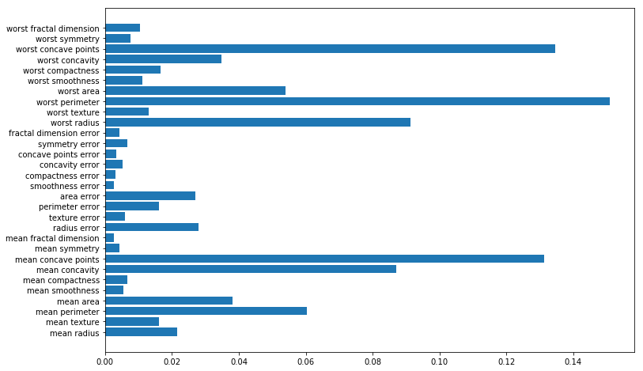

```python
# 特徴量の重要度をグラフに出力
n_features = len(bc.feature_names)
plt.figure(figsize=(12, 8))
plt.barh(range(n_features), rfc_2.feature_importances_ , align='center')
plt.yticks(np.arange(n_features), bc.feature_names)
plt.show()
```

以上の結果より､乳がんの判定においては以下の特徴量が特に重要であることがわかりました｡

1. worst perimeter ･･･ 最も長い細胞核の周囲
2. worst concave points ･･･ 最も多い凹みの個数
3. mean concave points ･･･ 平均の凹みの個数
4. worst radius ･･･ 最も長い半径
5. mean concavity ･･･ 最も大きな凹み

また､ランダムフォレストは**予測確率**を出力することもできます｡

```python
# 予測確率を出力する
rfc_2.predict_proba(X_2_test[0].reshape(1, -1))
```

```
array([[ 0.97,  0.03]])
```

## 11.8 勾配ブースティング木

勾配ブースティング木とは､**決定木を用いたブースティングの手法**です｡ひとつの決定木の間違いを修正するような決定木を逐次的につくることで､汎化性能の向上を目指します｡パラメータの最適化に勾配降下法を利用していることから､その名が付けられています｡

### 11.8.1 勾配ブースティング木のパラメータ

勾配ブースティング木は､**ランダムフォレストに比べてハイパーパラメータが汎化性能に及ぼす影響が大きいため**､その調整が重要になります｡特に重要なものは以下に示す3つです｡

#### n_estimators

n_estimatorsは､**｢合計でいくつの決定木を学習させるか｣**を表すパラメータです｡決定木の数が増えるほど微調整の回数が増えるので､大きくすればするほどモデルが複雑になり､小さくすればするほど単純になります｡

#### learning_rate

learning_rateは､**｢後に学習させる決定木が､前の決定木の間違いをどれだけ強く修正するか｣**を表すパラメータです｡learning_rateを大きくとるほど訓練データへの適合度が上がるため､正則化に該当するパラメータとなっています｡大きくするほどモデルが複雑になり､逆に､小さくするほど単純になります｡

#### max_depth

max_depthは､**｢ひとつひとつの決定木の深さ｣**を表すパラメータです｡勾配ブースティング木の性質を活かすのであれば､小さめに設定すべきです｡

### 11.8.2 学習の実行

勾配ブースティング木は､**sklearn.ensemble**に収録されている**GradientBoostingClassifier**を利用して実行できます｡

```python
# 勾配ブースティング木で学習させる
from sklearn.ensemble import GradientBoostingClassifier
gbct = GradientBoostingClassifier(random_state=0, max_depth=3, learning_rate=0.1)
gbct.fit(X_2_train, y_2_train)
```

```
GradientBoostingClassifier(criterion='friedman_mse', init=None,
              learning_rate=0.1, loss='deviance', max_depth=3,
              max_features=None, max_leaf_nodes=None,
              min_impurity_split=1e-07, min_samples_leaf=1,
              min_samples_split=2, min_weight_fraction_leaf=0.0,
              n_estimators=100, presort='auto', random_state=0,
              subsample=1.0, verbose=0, warm_start=False)
```

```python
# 正答率を出力
print('train accuracy: %.3f' % gbct.score(X_2_train, y_2_train))
print('test  accuracy: %.3f' % gbct.score(X_2_test, y_2_test))
```

```
train accuracy: 1.000
test  accuracy: 0.977
```

### 11.8.3 特徴量の重要度の出力

勾配ブースティング木も､ランダムフォレストと同様に特徴量の需要度を出力することができます｡

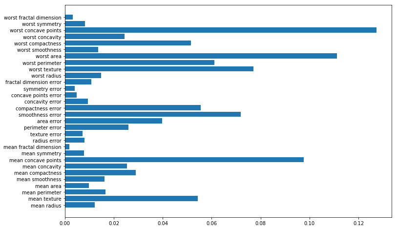

```python
# 特徴量の重要度をグラフに出力
n_features = len(bc.feature_names)
plt.figure(figsize=(12, 8))
plt.barh(range(n_features), gbct.feature_importances_ , align='center')
plt.yticks(np.arange(n_features), bc.feature_names)
plt.show()
```

予測確率を出力できる点も､ランダムフォレストと同様です｡

```python
# 予測確率を出力する
gbct.predict_proba(X_2_test[0].reshape(1, -1))
```

```
array([[ 0.99885011,  0.00114989]])
```

[figure not shown]

監修: 東京女子大学情報処理センター 浅川伸一